# Project 1: Urban Ministries of Durham

Jesus E. Vazquez

September 24, 2019

### Background Description

Urban Ministries of Durham assist around 6,000 people each year who need food, shelter, clothing and/or supportive services. Some of the programs that they offer is a (1) community shelter where people are given a place to sleep and assistance to help them find a home, a (2) Community Café serves three meals a day, seven days a week, 365 days a year, and a (3) food and clothing closet for those that either need food or clothing. Donations, just to as any homeless shelter, are important to maintain services, therefore communicating the importance of donations should be a high priority.

**Questions**

1. How is financial support to members of the Urban Ministries of Durham used?
2. What time of the year do members among the community make use of the Community Café?

**Approach**

### How is financial support used?

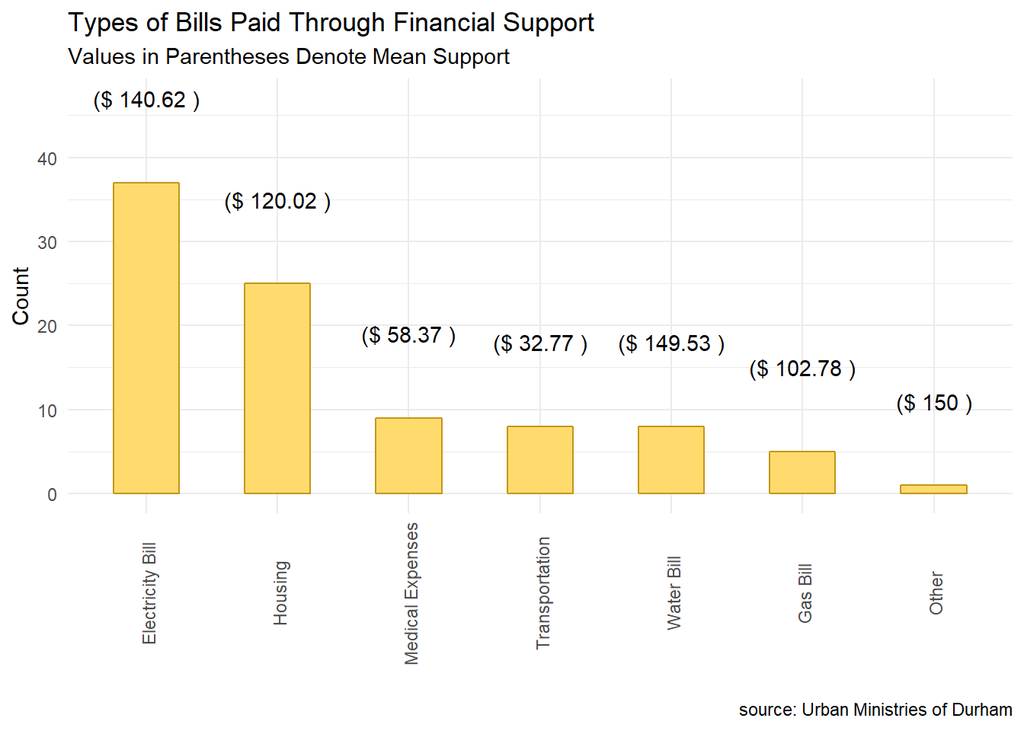

```r
library(tidyverse)

# Importing Data
mydf_original <- read_tsv("https://raw.githubusercontent.com/biodatascience/datasci611/gh-pages/data/project1_2019/UMD_Services_Provided_20190719.tsv")

################# Plot 1 #################

# Removing observations that have NAs in type of bill paid and financial support
mydf <- mydf_original[-which(is.na(mydf_original$`Financial Support`)),]
mydf <- mydf[-which(is.na(mydf$`Type of Bill Paid`)),]
mydf <- mydf[-which(mydf$`Financial Support` == 0),]

#changing all characters to lower case and grouping them by category
mydf$`Type of Bill Paid` <- (tolower(mydf$`Type of Bill Paid`))

for (i in 1:dim(mydf)[1]) {

    if(str_detect(mydf[i,14], c("duke")) || str_detect(mydf[i,14], c("power")) || str_detect(mydf[i,14], "electricity") || str_detect(mydf[i,14], "energy")){
        mydf[i,14] <- paste("Electricity Bill")
        next
    }

    if(str_detect(mydf[i,14], "water")){
        mydf[i,14] <- paste("Water Bill")
        next
    }

    if(str_detect(mydf[i,14], "bus") || str_detect(mydf[i,14], "greyhound") || str_detect(mydf[i,14], "ticket") || str_detect(mydf[i,14], "car")){
        mydf[i,14] <- paste("Transportation")
        next
    }

    if(str_detect(mydf[i,14], "rent") || str_detect(mydf[i,14], "mortgage") || str_detect(mydf[i,14], "deposit")){
        mydf[i,14] <- paste("Housing")
        next
    }

    if(str_detect(mydf[i,14], "gas") || str_detect(mydf[i,14], "heating")){
        mydf[i,14] <- paste("Gas Bill")
        next
    }

    if(str_detect(mydf[i,14], "prescription") || str_detect(mydf[i,14], "med") || str_detect(mydf[i,14], "hospital") || str_detect(mydf[i,14], "eyeglasses") || str_detect(mydf[i,14], "pharmacy")){
        mydf[i,14] <- paste("Medical Expenses")
        next
    }

    mydf[i,14] <- paste("Other")
}

# Getting a count financial support requests by type of bill
typesofbill <- as.data.frame(table(mydf$`Type of Bill Paid`))
colnames(typesofbill) <- c("name", "count")
typesofbill <- typesofbill[order(-typesofbill$count),]
mymeans <- aggregate(mydf$`Financial Support`, by=list(mydf$`Type of Bill Paid`), mean)
colnames(mymeans) <- c("name", "mean")

# Merging the count and means per airport. Normalized value will mean divided by the number of flights from that airport
finaldf <- merge(typesofbill, mymeans, by='name')
finaldf$mean <- round(finaldf$mean, 2)
finaldf$meandollar <- paste("($",finaldf$mean,")")

#Sort by count decreasing order
finaldf <- finaldf[order(-finaldf$count),]


# Plot 1

p1 <- ggplot(finaldf, aes(x= reorder(finaldf$name, -finaldf$count), y=finaldf$count)) + theme_minimal() +
    geom_bar(stat="identity", width=.5, fill = "#FFDB6D", color = "#C4961A") + geom_text(aes(x=finaldf$name, y=finaldf$count+10, label = finaldf$meandollar)) +
    labs(title="Types of Bills Paid Through Financial Support", subtitle = 'Values in Parentheses Denote Mean Support', caption="source: Urban Ministries of Durham", y = 'Count', x = '') +
    theme(axis.text.x = element_text(angle=90, vjust=0.6))
p1
```

As observed from the plot above we can see that among those given financial support, most of the bills paid were electricity bills with an average of $140.62 per bill. Other bills included housing such as rent and security deposit, medical expenses such as medications, transportation, water, gas, and other. With this information we can see that the financial support was approved to pay for necessities and not for other type of expenses.

### What time of the year do members among the community make use of the Community Café?

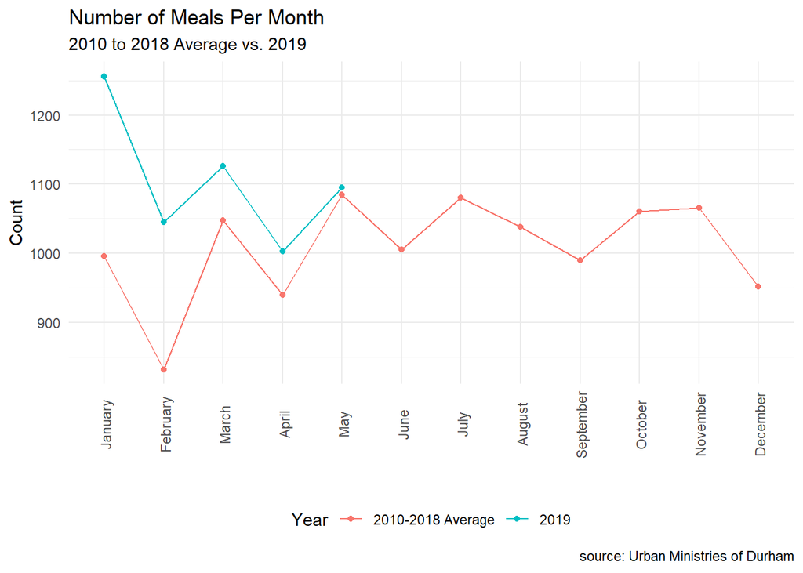

```r
################# Plot 2 #################
library(reshape2)
library(stringr)
mydf <- mydf_original
mydates <- colsplit(mydf$Date, "/", names = c("Month", "Day", "Year"))

mydf <- cbind(mydates, mydf) %>%
        subset(Year >= 2010, select = c('Food Provided for', "Month", "Year")) %>%
        subset(Year <= 2019)

mealspermonth <- aggregate(. ~ Month + Year, data = mydf, sum, na.rm = TRUE)
colnames(mealspermonth) <- c("Month", "Year", "Count")
mealspermonth$Year <- as.factor(mealspermonth$Year)

temporarydf <- spread(mealspermonth, key = Year, value = Count)
temporarydf$`2010-2018 Average` <- (temporarydf$`2010`+ temporarydf$`2011` + temporarydf$`2012` + temporarydf$`2013` + temporarydf$`2014` + temporarydf$`2015` + temporarydf$`2016` +temporarydf$`2017` + temporarydf$`2018`)/9
mealspermonth <- gather(temporarydf, "Year", "Count", 2:12)
mealspermonth <- subset(mealspermonth, Year %in% c("2019", "2010-2018 Average"))
mealspermonth <- mealspermonth[-which(mealspermonth$Year == "2019" & mealspermonth$Month >= 6),]

mealspermonth[which(mealspermonth$Month == 1),4] <- paste("January")
mealspermonth[which(mealspermonth$Month == 2),4] <- paste("February")
mealspermonth[which(mealspermonth$Month == 3),4] <- paste("March")
mealspermonth[which(mealspermonth$Month == 4),4] <- paste("April")
mealspermonth[which(mealspermonth$Month == 5),4] <- paste("May")
mealspermonth[which(mealspermonth$Month == 6),4] <- paste("June")
mealspermonth[which(mealspermonth$Month == 7),4] <- paste("July")
mealspermonth[which(mealspermonth$Month == 8),4] <- paste("August")
mealspermonth[which(mealspermonth$Month == 9),4] <- paste("September")
mealspermonth[which(mealspermonth$Month == 10),4] <- paste("October")
mealspermonth[which(mealspermonth$Month == 11),4] <- paste("November")
mealspermonth[which(mealspermonth$Month == 12),4] <- paste("December")

# Plot 2
p2 <-ggplot(mealspermonth, aes(x= reorder(V4, Month), y=Count, group=Year)) + theme_minimal() +
    geom_line(aes(color=Year)) +
    geom_point(aes(color=Year)) +
    labs(title="Number of Meals Per Month", subtitle = '2010 to 2018 Average vs. 2019', caption="source: Urban Ministries of Durham", y = 'Count', x = '') +
    theme(axis.text.x = element_text(angle=90, vjust=0.6), legend.position="bottom")
p2
```